# Question

A random procedure generated 50 measurements, which were organized into the [histogram](https://en.wikipedia.org/wiki/Histogram) shown below. You can assume the measurements are of a [continuous variable](https://en.wikipedia.org/wiki/Continuous_or_discrete_variable), such that every measurement is in one of the intervals (and not on a break).

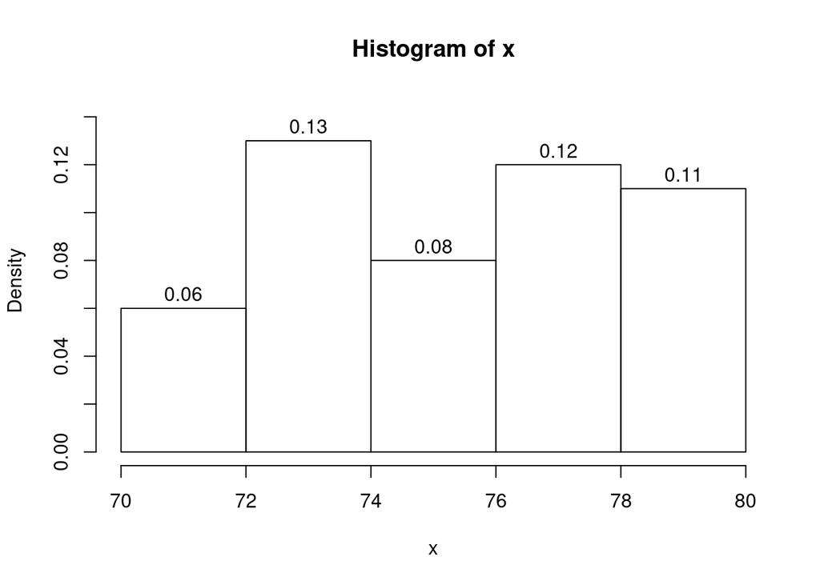

## Answerlist

- Evaluate $\text{prop}[\mathbf{x}<76]$.
- Evaluate $\text{prop}[\mathbf{x}>72]$.
- Evaluate $\text{prop}[|\mathbf{x}-74|<2]$.
- Evaluate $\text{prop}[|\mathbf{x}-75|>3]$.
- Evaluate boundary $b$ such that $\text{prop}[\mathbf{x}<b] = 0.54$.
- Evaluate boundary $b$ such that $\text{prop}[\mathbf{x}>b] = 0.46$.
- Evaluate radius $r$ such that $\text{prop}[|\mathbf{x}-73|<r] = 0.26$.
- Evaluate radius $r$ such that $\text{prop}[|\mathbf{x}-73|>r] = 0.74$.

# Solution

You may find it helpful to convert the densities to frequencies by multiplying each density by both the total sample size ($n=50$) and the width of the bar (2).

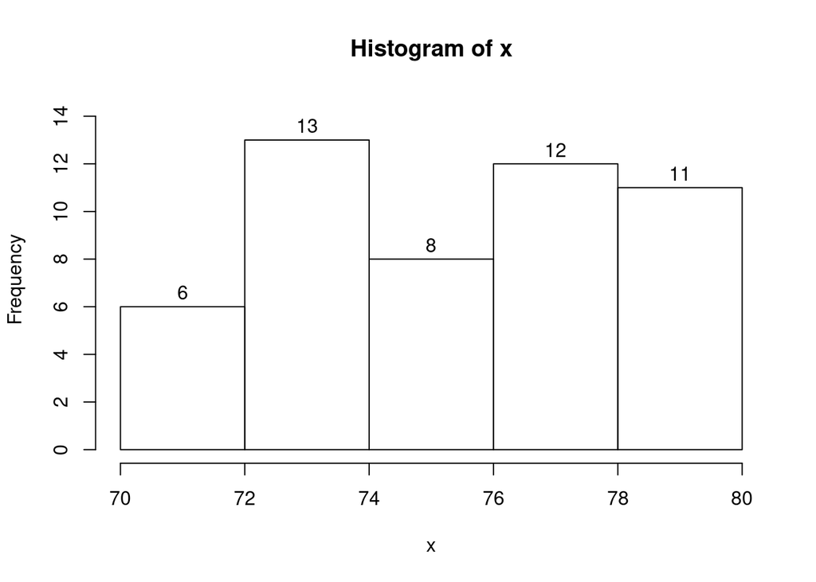

The first 4 questions involve adding up frequencies of the indicated intervals. The last 4 questions can be done by guessing and checking until something works.

## Answerlist

- There are 27 measurements less than 76. So, $\text{prop}[\mathbf{x}<76]=0.54$.
- There are 44 measurements more than 72. So, $\text{prop}[\mathbf{x}>72]=0.88$.
- There are 21 measurements closer than 2 units from 74. So, $\text{prop}[|\mathbf{x}-74|<2]=0.42$.
- There are 17 measurements further than 3 units from 75. So, $\text{prop}[|\mathbf{x}-75|>3]=0.34$.
- A boundary at $b=76$ has 27 measurements less than it. So, $\text{prop}[\mathbf{x}<76]=0.54$.
- A boundary at $b=76$ has 23 measurements more than it. So, $\text{prop}[\mathbf{x}>76]=0.46$.
- An interval with radius $r=1$ around center 73 contains 13 measurements. So, $\text{prop}[|\mathbf{x}-73|<1]=0.26$.
- An interval with radius $r=1$ around center 73 excludes 37 measurements. So, $\text{prop}[|\mathbf{x}-73|>1]=0.74$.

# Meta-information

extype: cloze exclozetype: num|num|num|num|num|num|num|num exsolution: 0.54|0.88|0.42|0.34|76|76|1|1 exname: read_histogram extol: 0.001 exextra[numwidth,character]: 999.99